# Assignment: Homework Hyndman Chapter 5 & 6 Exercises

## Question 7

Data set huron gives the water level of Lake Huron in feet from 1875 to 1972.

`#` Question 7(a) Plot the data and comment on its features.

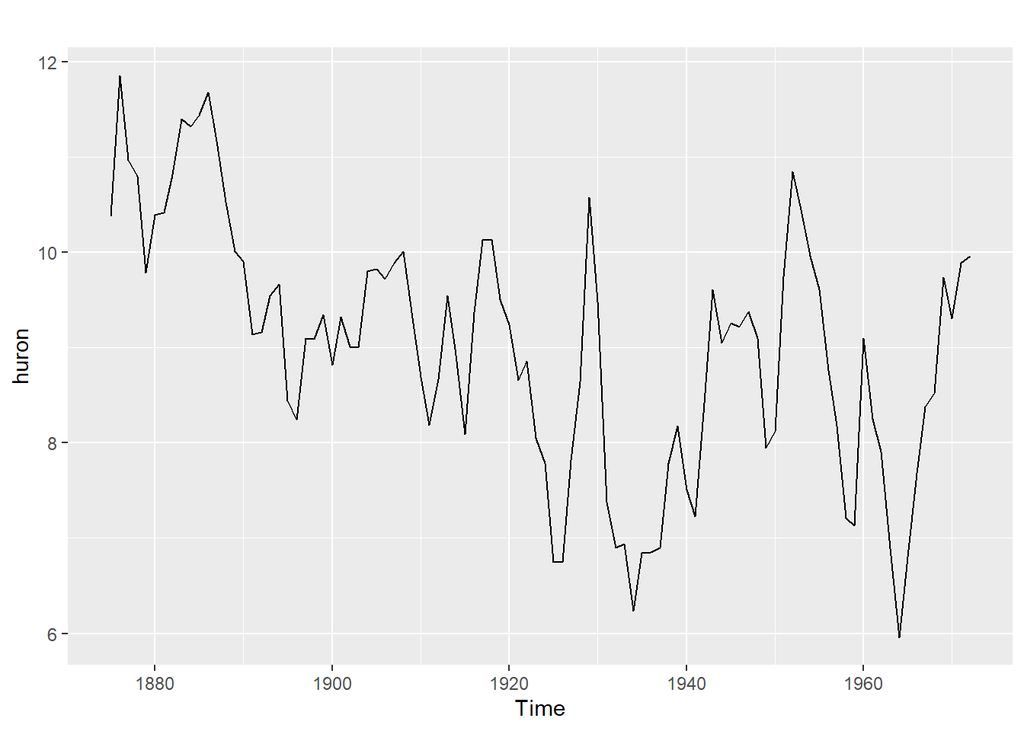

```r
autoplot(huron)
```

```r
str(huron)
```

```
##  Time-Series [1:98] from 1875 to 1972: 10.38 11.86 10.97 10.8 9.79 ...
```

`#` Question 7(b) Fit a linear regression and compare this to a piecewise linear trend model with a knot at 1915.

```r
# linear regression
tslm_huron <- tslm(huron ~ trend)
fc.tslm.huron <- forecast(tslm_huron, h=8)
# piecewise
t <- time(huron)
t.break <- 1915
t.P <- ts(pmax(0,t-t.break), start=1875)
tslm.pw <- tslm(huron ~ t + t.P)
  t_new <- t[length(t)]+seq(8)
  t.p.new <- t.P[length(t.P)]+seq(8)

newdata <- cbind(t=t_new,
                 t.P=t.p.new) %>%
  as.data.frame()


fc.tslm.pw.huron <- forecast(
  tslm.pw,
  newdata = newdata
  )
```

`#` Question 7(c) Generate forecasts from these two models for the period up to 1980 and comment on these.

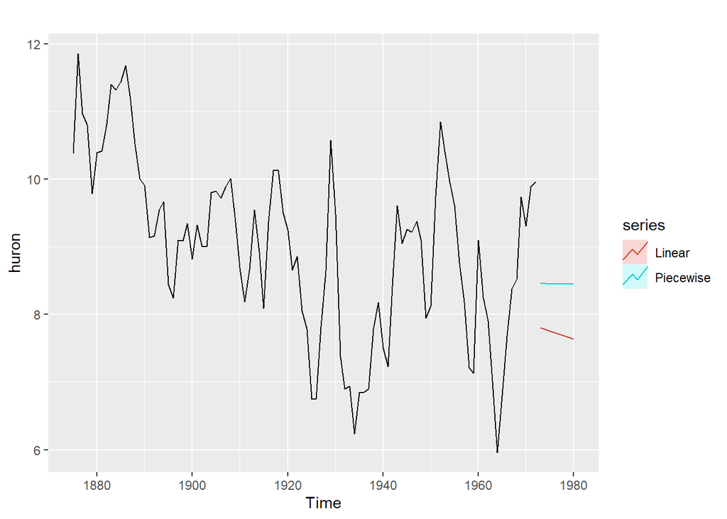

```r
autoplot(huron)+
  autolayer(fc.tslm.huron, series='Linear', PI=FALSE)+
  autolayer(fc.tslm.pw.huron, series='Piecewise',PI=FALSE)
```